# Customer Segmentation

20BCE1353

2023-03-08

```r
library(dplyr)
data <- read.csv("customer.csv")
head(data)
```

```
##       ID Gender Ever_Married Age Graduated    Profession Work_Experience
## 1 462809   Male           No  22        No    Healthcare               1
## 2 462643 Female          Yes  38       Yes      Engineer              NA
## 3 466315 Female          Yes  67       Yes      Engineer               1
## 4 461735   Male          Yes  67       Yes        Lawyer               0
## 5 462669 Female          Yes  40       Yes Entertainment              NA
## 6 461319   Male          Yes  56        No        Artist               0
##   Spending_Score Family_Size Var_1
## 1            Low           4 Cat_4
## 2        Average           3 Cat_4
## 3            Low           1 Cat_6
## 4           High           2 Cat_6
## 5           High           6 Cat_6
## 6        Average           2 Cat_6
```

```r
library(Hmisc)
describe(data)
```

```
## data
##
##  10  Variables      10695  Observations
## --------------------------------------------------------------------------------
## ID
##        n  missing distinct     Info     Mean      Gmd      .05      .10
##    10695        0     8363        1   463468     3003   459422   459867
##      .25      .50      .75      .90      .95
##   461221   463451   465734   467086   467520
##
## lowest : 458982 458983 458984 458985 458986, highest: 467969 467971 467972 467973 467974
## --------------------------------------------------------------------------------
## Gender
##        n  missing distinct
##    10695        0        2
##
## Value      Female   Male
## Frequency    4854   5841
## Proportion  0.454  0.546
## --------------------------------------------------------------------------------
## Ever_Married
##        n  missing distinct
##    10505      190        2
##
## Value         No   Yes
## Frequency   4342  6163
## Proportion 0.413 0.587
## --------------------------------------------------------------------------------
## Age
##        n  missing distinct     Info     Mean      Gmd      .05      .10
##    10695        0       67        1    43.51    18.75       20       25
##      .25      .50      .75      .90      .95
##       30       41       53       69       77
##
## lowest : 18 19 20 21 22, highest: 85 86 87 88 89
## --------------------------------------------------------------------------------
## Graduated
##        n  missing distinct
##    10593      102        2
##
```

[output cut: 44 more lines]

```
##
## Value          1     2     3     4     5     6     7     8     9
## Frequency   1965  3158  1952  1823   812   290   122    65    60
## Proportion 0.192 0.308 0.190 0.178 0.079 0.028 0.012 0.006 0.006
## --------------------------------------------------------------------------------
## Var_1
##        n  missing distinct
##    10587      108        7
##
## lowest : Cat_1 Cat_2 Cat_3 Cat_4 Cat_5, highest: Cat_3 Cat_4 Cat_5 Cat_6 Cat_7
##
## Value      Cat_1 Cat_2 Cat_3 Cat_4 Cat_5 Cat_6 Cat_7
## Frequency    167   563  1089  1475   114  6910   269
## Proportion 0.016 0.053 0.103 0.139 0.011 0.653 0.025
## --------------------------------------------------------------------------------
```

### Dropping the unnecessary column Var_1

```r
drops <- c("Var_1")
data <- data[ ,!(names(data) %in% drops)]

head(data)
```

```
##       ID Gender Ever_Married Age Graduated    Profession Work_Experience
## 1 462809   Male           No  22        No    Healthcare               1
## 2 462643 Female          Yes  38       Yes      Engineer              NA
## 3 466315 Female          Yes  67       Yes      Engineer               1
## 4 461735   Male          Yes  67       Yes        Lawyer               0
## 5 462669 Female          Yes  40       Yes Entertainment              NA
## 6 461319   Male          Yes  56        No        Artist               0
##   Spending_Score Family_Size
## 1            Low           4
## 2        Average           3
## 3            Low           1
## 4           High           2
## 5           High           6
## 6        Average           2
```

### Checking for missing values

```r
#handling blank values and NA values:
data[data==""] <- NA

lapply(data, function(x) {length(which(is.na(x)))})
```

```
## $ID
## [1] 0
##
## $Gender
## [1] 0
##
## $Ever_Married
## [1] 190
##
## $Age
## [1] 0
##
## $Graduated
## [1] 102
##
## $Profession
## [1] 162
##
## $Work_Experience
## [1] 1098
##
## $Spending_Score
## [1] 0
##
## $Family_Size
## [1] 448
```

Attributes Ever_Married, Graduated, Profession, Work_Experience, and Family_Size have missing values. Ever_Married, Graduated and Profession are categorical variables. Work_Experience and Family_Size are numeric.

```r
getmode <- function(v) {
    uniqv <- unique(v)
    uniqv[which.max(tabulate(match(v, uniqv)))]
}
```

### Replacing with mode for categorical and mean for continuous

```r
data$Ever_Married[is.na(data$Ever_Married)] <- getmode(data$Ever_Married)
data$Graduated[is.na(data$Graduated)] <- getmode(data$Graduated)
data$Profession[is.na(data$Profession)] <- getmode(data$Profession)
data$Work_Experience[is.na(data$Work_Experience)] <-mean(data$Work_Experience, na.rm = TRUE)
data$Family_Size[is.na(data$Family_Size)]<-mean(data$Family_Size,na.rm=TRUE)
```

### Exploratory Data Analysis

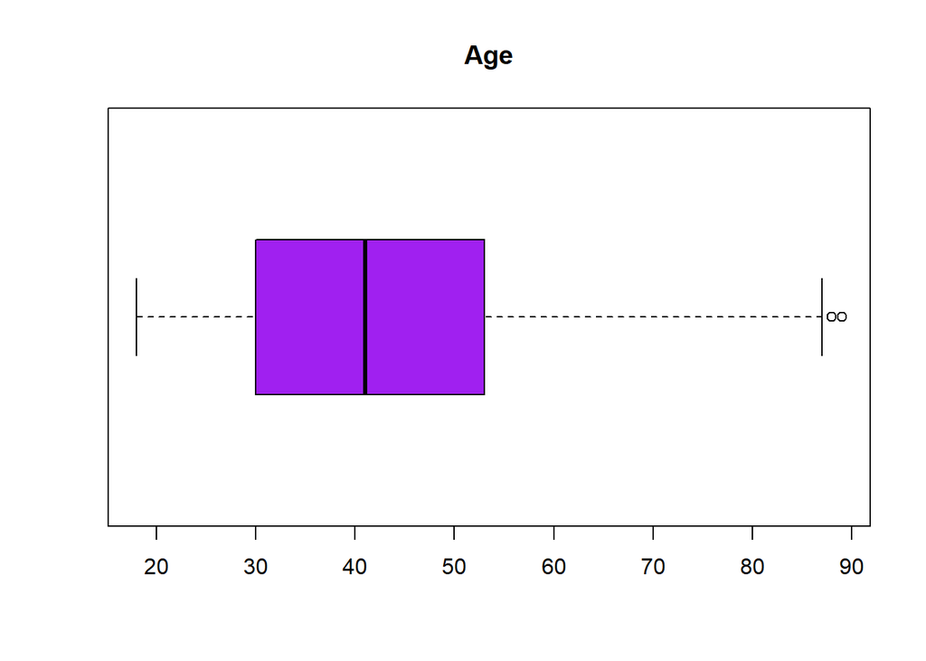

```r
boxplot(data$Age, horizontal = TRUE,col = 'Purple',main="Age")
```

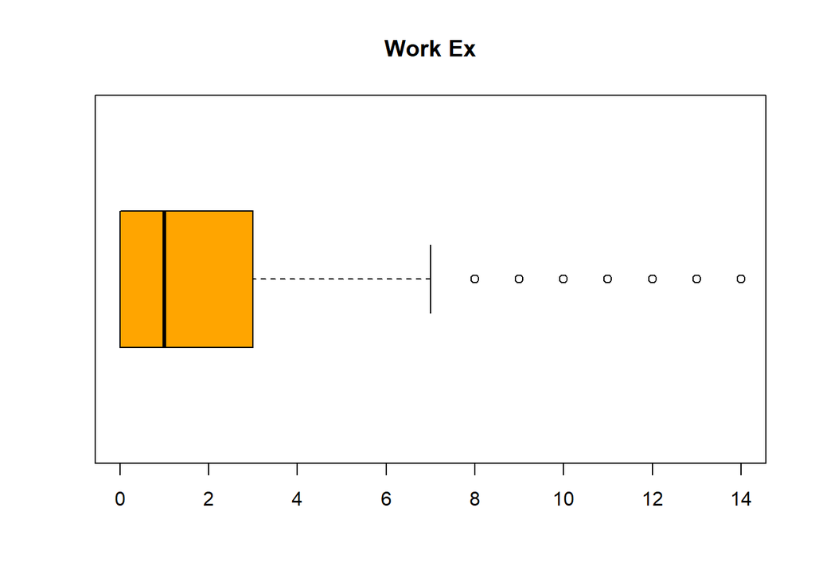

```r
boxplot(data$Work_Experience, horizontal = TRUE,col = 'Orange',main="Work Ex")
```

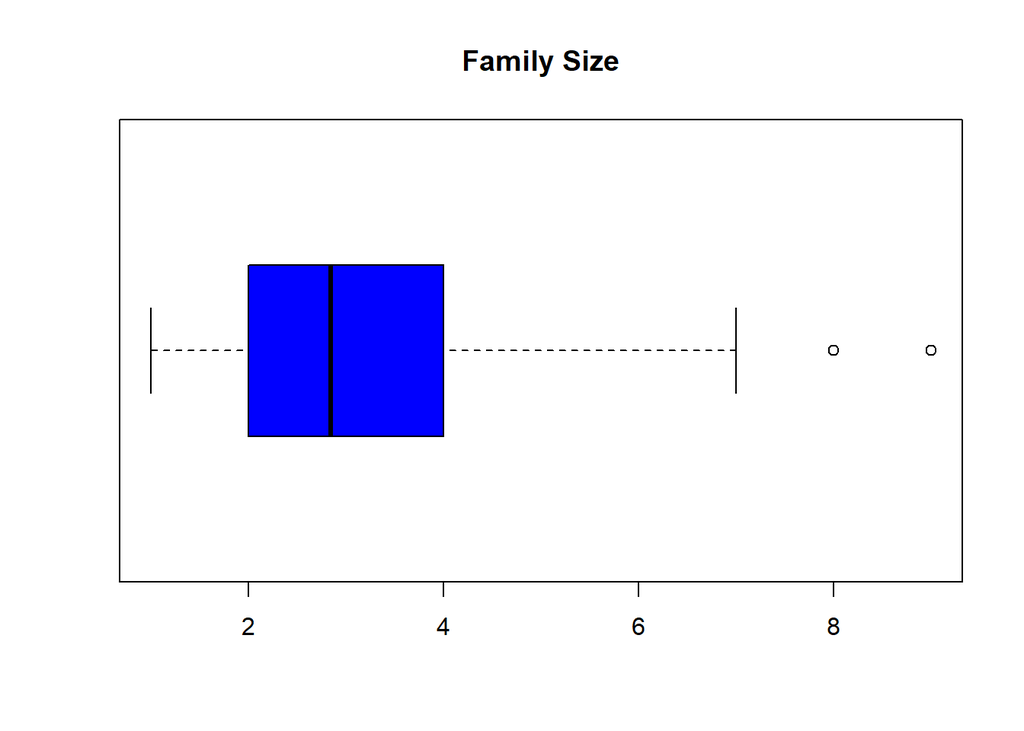

```r
boxplot(data$Family_Size, horizontal = TRUE,col = 'Blue',main="Family Size")
```

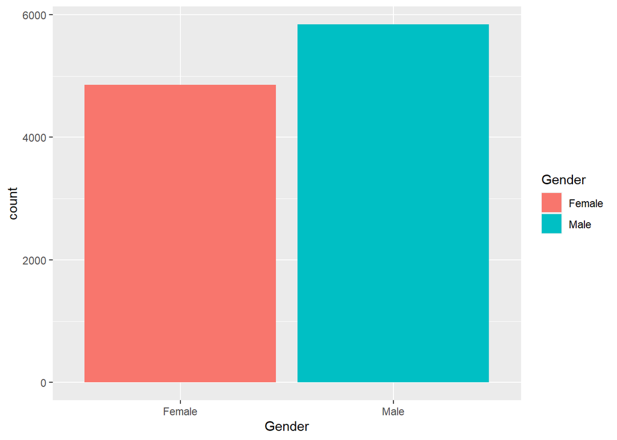

```r
library(ggplot2)
ggplot(data) + geom_bar(aes(x = Gender, fill = Gender))
```

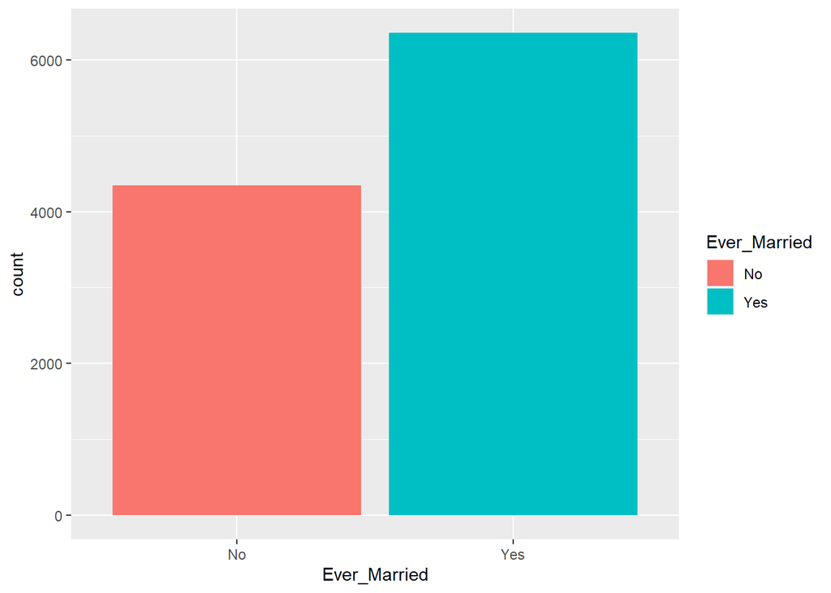

```r
ggplot(data) + geom_bar(aes(x = Ever_Married, fill = Ever_Married))
```

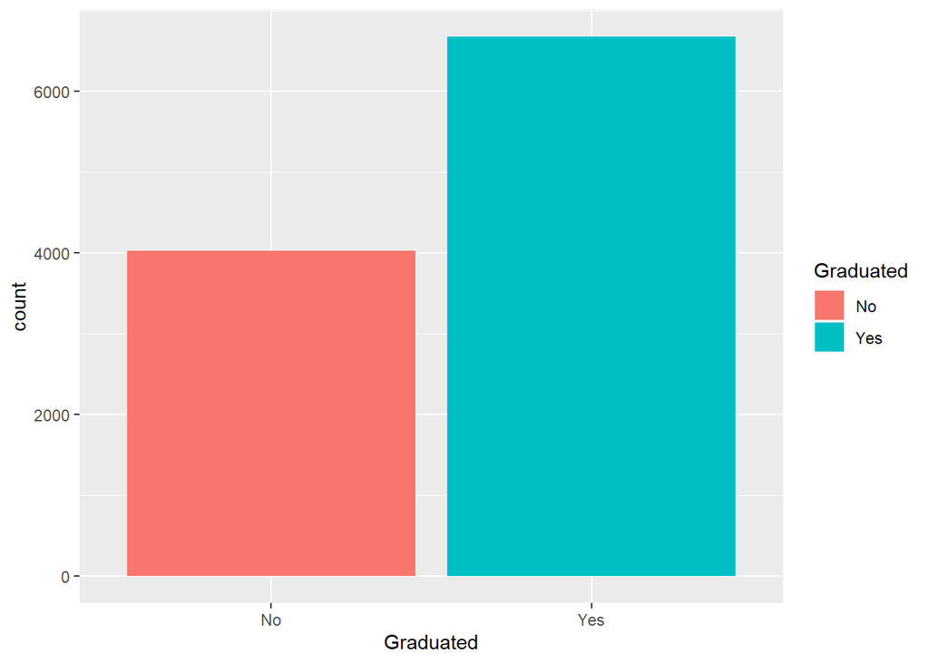

```r
ggplot(data) + geom_bar(aes(x = Graduated, fill = Graduated))
```

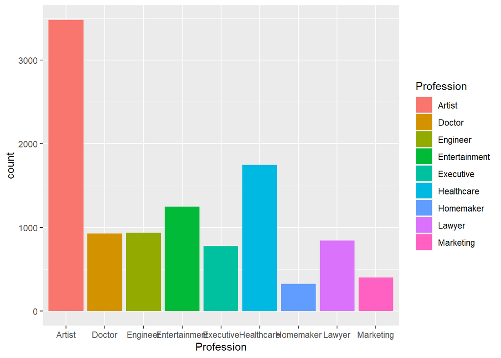

```r
ggplot(data) + geom_bar(aes(x = Profession, fill = Profession))
```

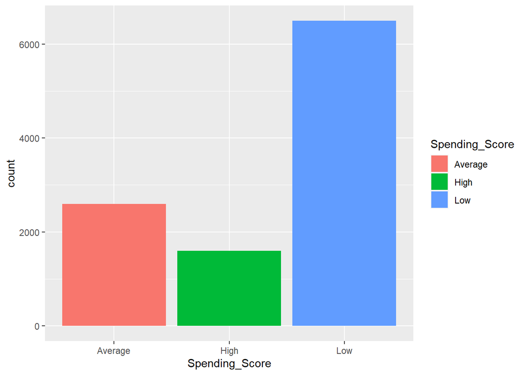

```r
ggplot(data) + geom_bar(aes(x = Spending_Score, fill = Spending_Score))
```

The data set is fairly balanced with 20-30% more Male customers than Female, mostly married individuals, majority graduated education, with a high number of individuals who work as an “Artist”.  
Most customers also tend to spend less in general.

### Encoding categorical values using One Hot encoding

```r
library(fastDummies)
cluster_data<-dummy_cols(data)

cat <- c("ID","Gender","Ever_Married","Graduated","Profession","Spending_Score")
cluster_data<-cluster_data[ , !(names(cluster_data) %in% cat)]

head(cluster_data)
```

```
##   Age Work_Experience Family_Size Gender_Female Gender_Male Ever_Married_No
## 1  22        1.000000           4             0           1               1
## 2  38        2.619777           3             1           0               0
## 3  67        1.000000           1             1           0               0
## 4  67        0.000000           2             0           1               0
## 5  40        2.619777           6             1           0               0
## 6  56        0.000000           2             0           1               0
##   Ever_Married_Yes Graduated_No Graduated_Yes Profession_Artist
## 1                0            1             0                 0
## 2                1            0             1                 0
## 3                1            0             1                 0
## 4                1            0             1                 0
## 5                1            0             1                 0
## 6                1            1             0                 1
##   Profession_Doctor Profession_Engineer Profession_Entertainment
```

[output cut: 27 more lines]

Now, the categorical variables are encoded to a numeric type that makes it easy for unsupervised learning algorithms to use.

# Clustering the customers into different groups using multiple clustering algorithms

```r
library(cluster)
library(factoextra)
```

### Elbow Plot

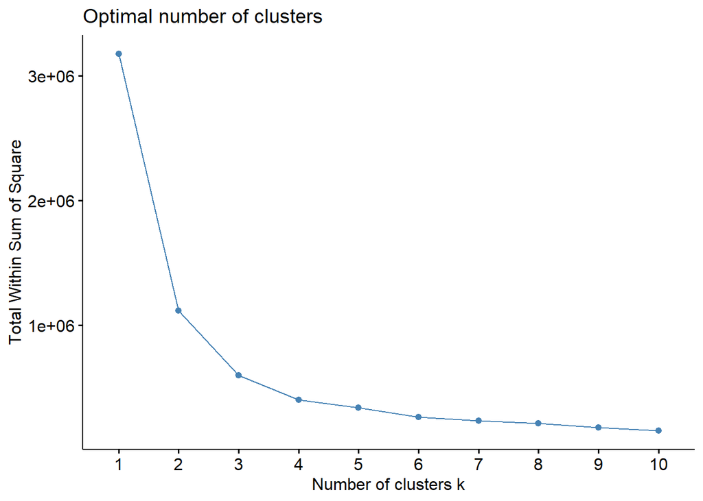

```r
fviz_nbclust(cluster_data, kmeans, method = "wss")
```

From the elbow plot, we observe an elbow at k = 3 clusters for k means clustering.

### 1. K-Means clustering with K = 3

```r
set.seed(240) # Setting seed
kmeans_1 <- kmeans(cluster_data, centers = 3, nstart = 20)

table(kmeans_1$cluster)
```

```
##
##    1    2    3
## 2136 4400 4159
```

```r
data$cluster<-kmeans_1$cluster
```

### 2. Hierarchical Clustering - using Complete linkage

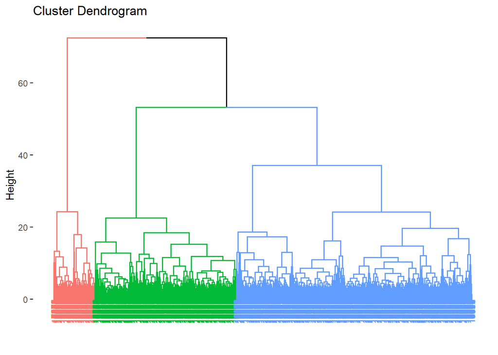

```r
set.seed(240)

d <- dist(cluster_data, method = "euclidian")
hclus_1 <- hclust(d, method = "complete")

fviz_dend(hclus_1, k = 3, cex = 0.6)
```

```r
hclust_fit <- cutree(hclus_1, k = 3)
table(hclust_fit)
```

```
## hclust_fit
##    1    2    3
## 3617 6022 1056
```

```r
data$hcluster<-hclust_fit
```

```r
library(ppclust)
```

### 3. Fuzzy C-Means Clustering

```r
fcm_fit <- fcm(cluster_data, centers= 3)
table(fcm_fit$cluster)
```

```
##
##    1    2    3
## 4209 4463 2023
```

```r
data$fcmcluster <- fcm_fit$cluster
```

### 4. K-Medoids Clustering

```r
pam_fit <- pam(cluster_data, k = 3)
table(pam_fit$clustering)
```

```
##
##    1    2    3
## 3726 4489 2480
```

```r
data$pamcluster <- pam_fit$cluster
```

### Visualizing cluster separation by pairs of attributes

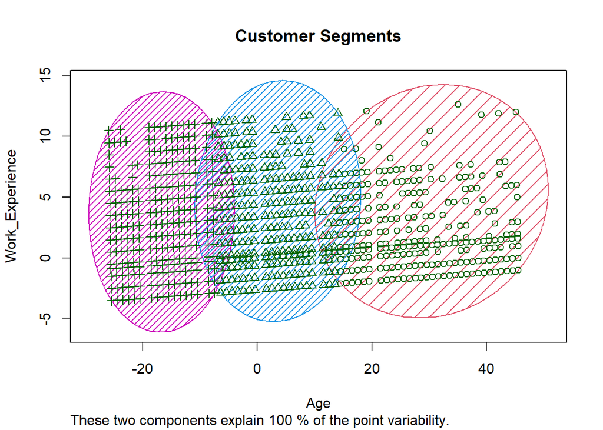

```r
y_kmeans <- kmeans_1$cluster

clusplot(data[, c("Age", "Work_Experience")],
         y_kmeans,
         lines = 0,
         shade = TRUE,
         color = TRUE,
         labels = 0,
         plotchar = TRUE,
         span = TRUE,
         main = paste("Customer Segments"),
         xlab = 'Age',
         ylab = 'Work_Experience')
```

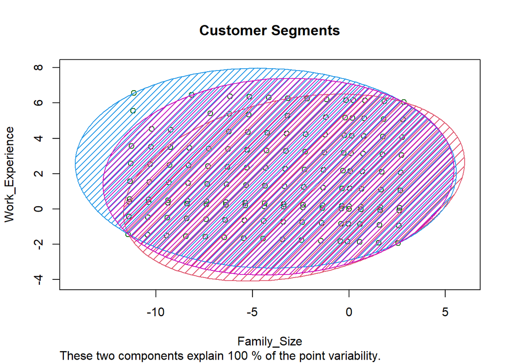

```r
clusplot(data[, c("Family_Size", "Work_Experience")],
         y_kmeans,
         lines = 0,
         shade = TRUE,
         color = TRUE,
         labels = 0,
         plotchar = FALSE,
         span = TRUE,
         main = paste("Customer Segments"),
         xlab = 'Family_Size',
         ylab = 'Work_Experience')
```

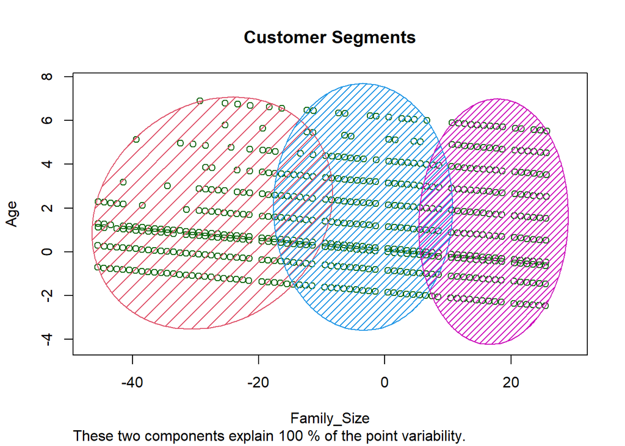

```r
clusplot(data[, c("Family_Size", "Age")],
         y_kmeans,
         lines = 0,
         shade = TRUE,
         color = TRUE,
         labels = 0,
         plotchar = FALSE,
         span = TRUE,
         main = paste("Customer Segments"),
         xlab = 'Family_Size',
         ylab = 'Age')
```

When viewing data points based on age and work experience, we can see that the clusters are divided in different age groups Here we observe overlapping clusters which means that these Work Experience and Family Size are not attributes that strongly define a cluster. Here it is observed that Family Size also varies in each cluster across multiple age groups.

```r
data %>% group_by(cluster) %>%
  summarise(Mean_Age=mean(Age), Work_Experience=mean(Work_Experience),Family_Size=mean(Family_Size),
            Graduated=getmode(Graduated),Gender=getmode(Gender),
       Married=getmode(Ever_Married),Profession=getmode(Profession),
            Spend=getmode(Spending_Score))
```

```
## # A tibble: 3 × 9
##   cluster Mean_Age Work_Experience Family…¹ Gradu…² Gender Married Profe…³ Spend
##     <int>    <dbl>           <dbl>    <dbl> <chr>   <chr>  <chr>   <chr>   <chr>
## 1       1     70.2            1.49     2.29 Yes     Male   Yes     Lawyer  Low
## 2       2     45.4            2.72     2.69 Yes     Male   Yes     Artist  Low
## 3       3     27.8            3.09     3.29 No      Male   No      Health… Low
## # … with abbreviated variable names ¹Family_Size, ²Graduated, ³Profession
```

From the summary of the clusters, we can observe that, yes, the average age is different for all three clusters. The youngest group also has more participants who are unmarried and not yet graduated.

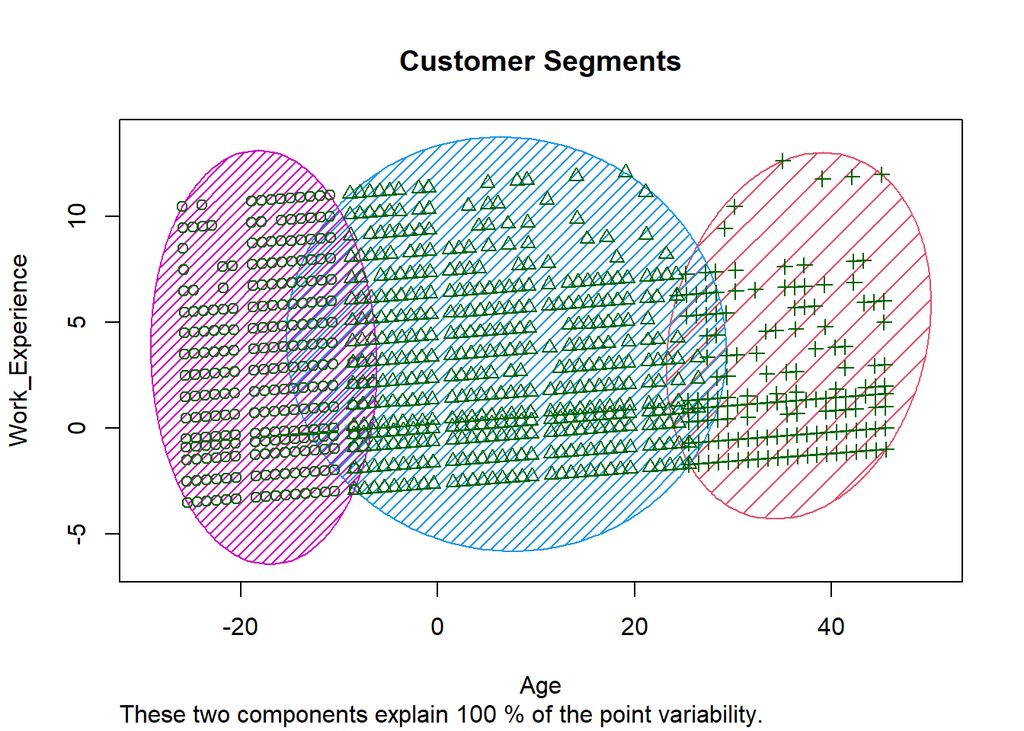

```r
y_hclust <- hclust_fit

clusplot(data[, c("Age", "Work_Experience")],
         y_hclust,
         lines = 0,
         shade = TRUE,
         color = TRUE,
         labels = 0,
         plotchar = TRUE,
         span = TRUE,
         main = paste("Customer Segments"),
         xlab = 'Age',
         ylab = 'Work_Experience')
```

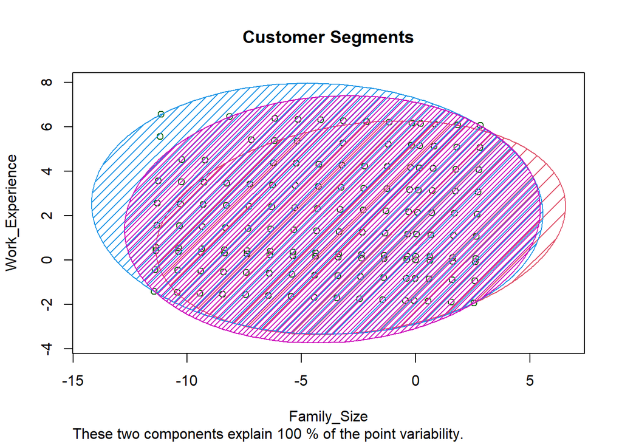

```r
clusplot(data[, c("Family_Size", "Work_Experience")],
         y_hclust,
         lines = 0,
         shade = TRUE,
         color = TRUE,
         labels = 0,
         plotchar = FALSE,
         span = TRUE,
         main = paste("Customer Segments"),
         xlab = 'Family_Size',
         ylab = 'Work_Experience')
```

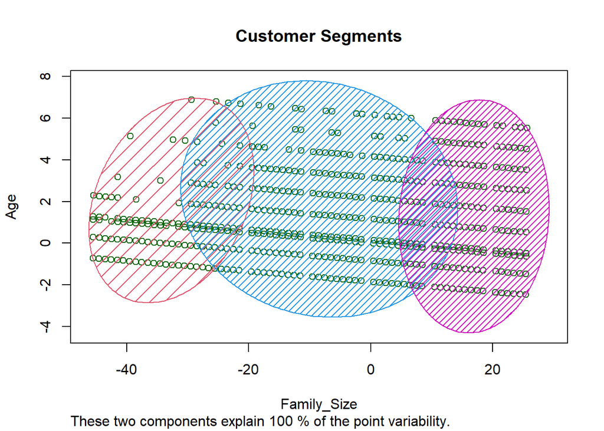

```r
clusplot(data[, c("Family_Size", "Age")],
         y_hclust,
         lines = 0,
         shade = TRUE,
         color = TRUE,
         labels = 0,
         plotchar = FALSE,
         span = TRUE,
         main = paste("Customer Segments"),
         xlab = 'Family_Size',
         ylab = 'Age')
```

Visually, the clusters formed are pretty similar with similar conclusions to k-means clustering.

Summary of each cluster as clustered by hierarchical clustering

```r
data %>% group_by(hcluster) %>%
  summarise(Mean_Age=mean(Age), Work_Experience=mean(Work_Experience),Family_Size=mean(Family_Size),
            Graduated=getmode(Graduated),Gender=getmode(Gender),
       Married=getmode(Ever_Married),Profession=getmode(Profession),
            Spend=getmode(Spending_Score))
```

```
## # A tibble: 3 × 9
##   hcluster Mean_Age Work_Experience Famil…¹ Gradu…² Gender Married Profe…³ Spend
##      <int>    <dbl>           <dbl>   <dbl> <chr>   <chr>  <chr>   <chr>   <chr>
## 1        1     26.7            3.01    3.41 No      Male   No      Health… Low
## 2        2     47.6            2.61    2.65 Yes     Male   Yes     Artist  Low
## 3        3     77.9            1.35    2.00 Yes     Male   Yes     Lawyer  High
## # … with abbreviated variable names ¹Family_Size, ²Graduated, ³Profession
```

It is observed that, similar to K-means clustering, age is a primary factor for cluster differentiation. In this case, it is observed that people in one of the clusters (highest age group) has higher spending patterns than other groups.

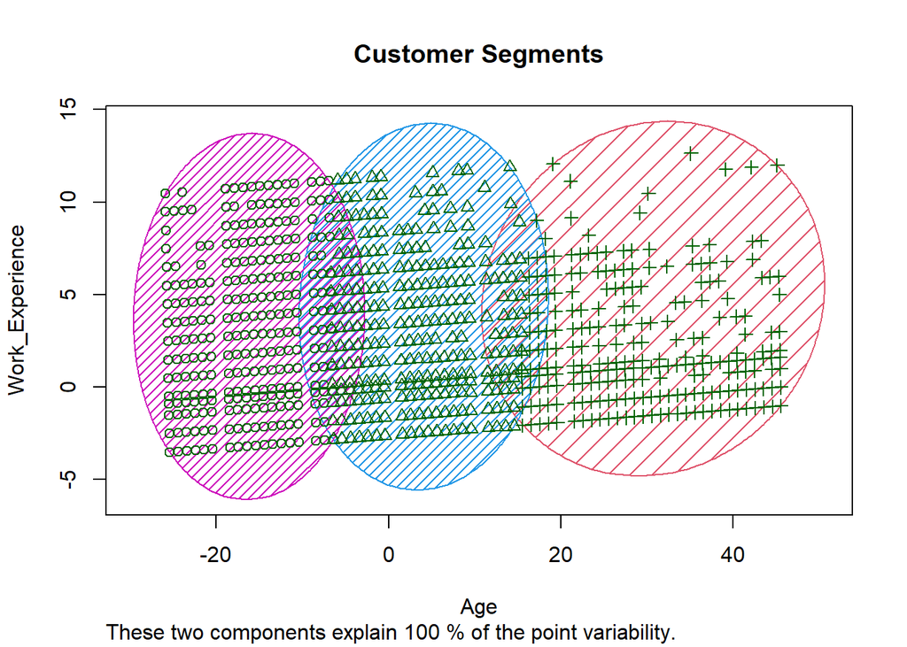

```r
y_hclust <- fcm_fit$cluster

clusplot(data[, c("Age", "Work_Experience")],
         y_hclust,
         lines = 0,
         shade = TRUE,
         color = TRUE,
         labels = 0,
         plotchar = TRUE,
         span = TRUE,
         main = paste("Customer Segments"),
         xlab = 'Age',
         ylab = 'Work_Experience')
```

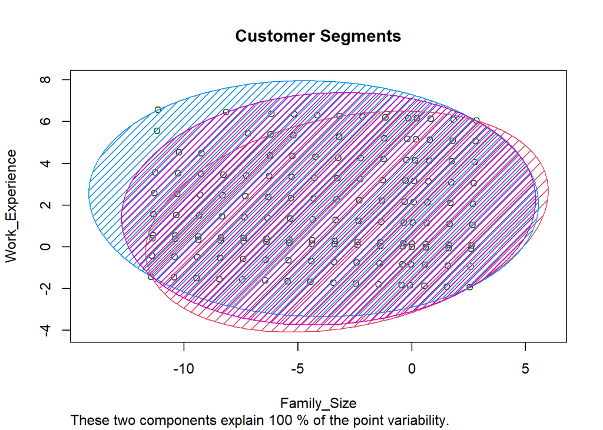

```r
clusplot(data[, c("Family_Size", "Work_Experience")],
         y_hclust,
         lines = 0,
         shade = TRUE,
         color = TRUE,
         labels = 0,
         plotchar = FALSE,
         span = TRUE,
         main = paste("Customer Segments"),
         xlab = 'Family_Size',
         ylab = 'Work_Experience')
```

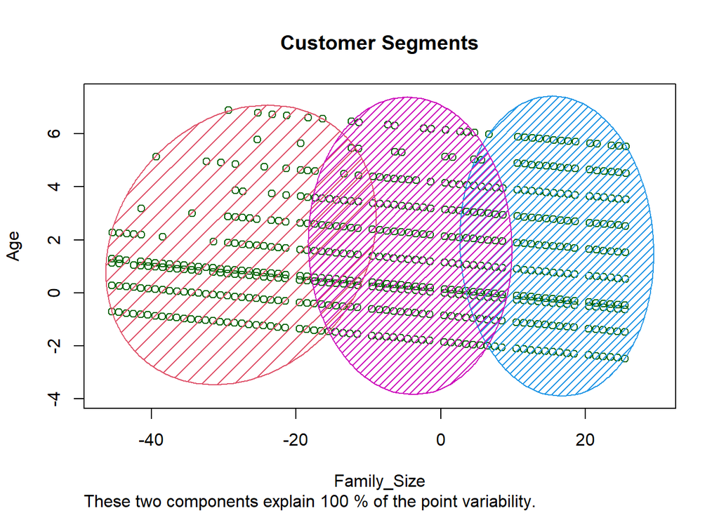

```r
clusplot(data[, c("Family_Size", "Age")],
         y_hclust,
         lines = 0,
         shade = TRUE,
         color = TRUE,
         labels = 0,
         plotchar = FALSE,
         span = TRUE,
         main = paste("Customer Segments"),
         xlab = 'Family_Size',
         ylab = 'Age')
```

Fuzzy C-Means clustering shows similarly separated clusters to K-Means and Hierarchical clustering.

Summary of each cluster as clustered by Fuzzy C-Means clustering

```r
data %>% group_by(fcmcluster) %>%
  summarise(Mean_Age=mean(Age), Work_Experience=mean(Work_Experience),Family_Size=mean(Family_Size),
            Graduated=getmode(Graduated),Gender=getmode(Gender),
       Married=getmode(Ever_Married),Profession=getmode(Profession),
            Spend=getmode(Spending_Score))
```

```
## # A tibble: 3 × 9
##   fcmcluster Mean_Age Work_Experi…¹ Famil…² Gradu…³ Gender Married Profe…⁴ Spend
##        <int>    <dbl>         <dbl>   <dbl> <chr>   <chr>  <chr>   <chr>   <chr>
## 1          1     27.9          3.16    3.29 No      Male   No      Health… Low
## 2          2     45.8          2.64    2.69 Yes     Male   Yes     Artist  Low
## 3          3     70.9          1.44    2.27 Yes     Male   Yes     Lawyer  Low
## # … with abbreviated variable names ¹Work_Experience, ²Family_Size, ³Graduated,
## #   ⁴Profession
```

Once again, Age is a primary differentiating factor for each cluster. Family size is also evenly split between each cluster.

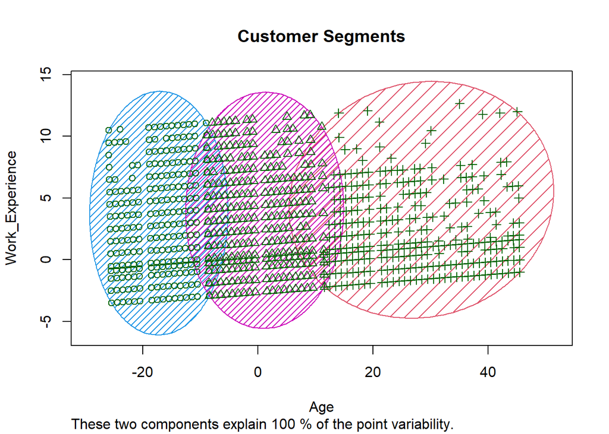

```r
y_hclust <- pam_fit$cluster

clusplot(data[, c("Age", "Work_Experience")],
         y_hclust,
         lines = 0,
         shade = TRUE,
         color = TRUE,
         labels = 0,
         plotchar = TRUE,
         span = TRUE,
         main = paste("Customer Segments"),
         xlab = 'Age',
         ylab = 'Work_Experience')
```

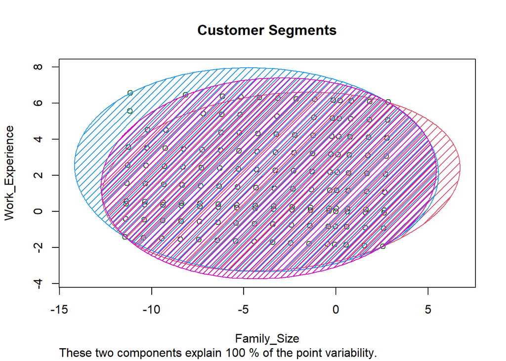

```r
clusplot(data[, c("Family_Size", "Work_Experience")],
         y_hclust,
         lines = 0,
         shade = TRUE,
         color = TRUE,
         labels = 0,
         plotchar = FALSE,
         span = TRUE,
         main = paste("Customer Segments"),
         xlab = 'Family_Size',
         ylab = 'Work_Experience')
```

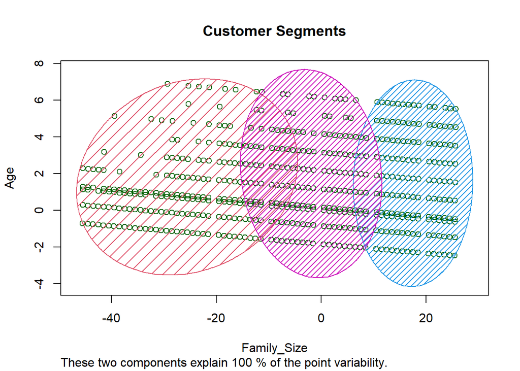

```r
clusplot(data[, c("Family_Size", "Age")],
         y_hclust,
         lines = 0,
         shade = TRUE,
         color = TRUE,
         labels = 0,
         plotchar = FALSE,
         span = TRUE,
         main = paste("Customer Segments"),
         xlab = 'Family_Size',
         ylab = 'Age')
```

Lastly, even K-Medoids clustering shows similar clusters for the pairs of numeric attributes chosen.

Summary of each cluster as clustered by K-Medoids clustering

```r
data %>% group_by(pamcluster) %>%
  summarise(Mean_Age=mean(Age), Work_Experience=mean(Work_Experience),Family_Size=mean(Family_Size),
            Graduated=getmode(Graduated),Gender=getmode(Gender),
       Married=getmode(Ever_Married),Profession=getmode(Profession),
            Spend=getmode(Spending_Score))
```

```
## # A tibble: 3 × 9
##   pamcluster Mean_Age Work_Experi…¹ Famil…² Gradu…³ Gender Married Profe…⁴ Spend
##        <int>    <dbl>         <dbl>   <dbl> <chr>   <chr>  <chr>   <chr>   <chr>
## 1          1     26.9          3.02    3.37 No      Male   No      Health… Low
## 2          2     43.6          2.90    2.68 Yes     Male   Yes     Artist  Low
## 3          3     68.3          1.50    2.34 Yes     Male   Yes     Lawyer  Low
## # … with abbreviated variable names ¹Work_Experience, ²Family_Size, ³Graduated,
## #   ⁴Profession
```

# Performance metrics of the different clusters

### 1. Dunn Index:

```r
library(clValid)
hclust_dunn <- dunn(d, hclust_fit)
kmeans_dunn <- dunn(d, kmeans_1$cluster)
pam_dunn <- dunn(d, pam_fit$clustering)
fcm_dunn <- dunn(d, fcm_fit$cluster)
```

```r
dunn_comparison <- matrix(c(kmeans_dunn, hclust_dunn, fcm_dunn, pam_dunn))
rownames(dunn_comparison) <- c("KMeans", "Hclust", "Fuzzy C-Means", "KMedoids")
colnames(dunn_comparison) <- c("Dunn Index")

as.table(dunn_comparison)
```

```
##               Dunn Index
## KMeans        0.02932312
## Hclust        0.02688988
## Fuzzy C-Means 0.03017858
## KMedoids      0.01035988
```

The Dunn Index is the ratio of the smallest distance between observations not in the same cluster to the largest intra-cluster distance. The Dunn Index has a value between zero and infinity, and should be maximized.  
Here, **Fuzzy C-Means** clustering shows the highest value of the Dunn Index by a small margin.

### 2. Calinski-Harabasz index

```r
library(fpc)
hclust_calinhara <- calinhara(cluster_data, hclust_fit)
kmeans_calinhara <- calinhara(cluster_data, kmeans_1$cluster)
pam_calinhara <- calinhara(cluster_data, pam_fit$clustering)
fcm_calinhara <- calinhara(cluster_data, fcm_fit$cluster)
```

```r
calinhara_comparison <- matrix(c(kmeans_calinhara, hclust_calinhara, fcm_calinhara, pam_calinhara))
rownames(calinhara_comparison) <- c("KMeans", "Hclust", "Fuzzy C-Means", "KMedoids")
colnames(calinhara_comparison) <- c("Calinhara value")

as.table(calinhara_comparison)
```

```
##               Calinhara value
## KMeans               23013.48
## Hclust               16187.09
## Fuzzy C-Means        22974.96
## KMedoids             22357.89
```

The Calinhara Index (also known as Variance ratio criterion) is a measure of how similar an object is to its own cluster (cohesion) compared to other clusters (separation). Here cohesion is estimated based on the distances from the data points in a cluster to its cluster centroid and separation is based on the distance of the cluster centroids from the global centroid. A higher value of this indicates tighter grouped clusters and more separation between clusters.  
Here, we observe a functional tie between **Fuzzy C-Means** and **KMeans** clustering.

### The selected clustering technique is Fuzzy C-Means clustering, based on the performance metrics.

```r
cluster_data$cluster <- kmeans_1$cluster
cluster_data$hcluster <- hclust_fit
cluster_data$fcmcluster <- fcm_fit$cluster
cluster_data$pamcluster <- pam_fit$clustering
```

```r
head(data)
```

```
##       ID Gender Ever_Married Age Graduated    Profession Work_Experience
## 1 462809   Male           No  22        No    Healthcare        1.000000
## 2 462643 Female          Yes  38       Yes      Engineer        2.619777
## 3 466315 Female          Yes  67       Yes      Engineer        1.000000
## 4 461735   Male          Yes  67       Yes        Lawyer        0.000000
## 5 462669 Female          Yes  40       Yes Entertainment        2.619777
## 6 461319   Male          Yes  56        No        Artist        0.000000
##   Spending_Score Family_Size cluster hcluster fcmcluster pamcluster
## 1            Low           4       3        1          1          1
## 2        Average           3       2        2          2          2
## 3            Low           1       1        2          3          3
## 4           High           2       1        2          3          3
## 5           High           6       2        2          2          2
## 6        Average           2       2        2          2          3
```

# Training models to predict what cluster a user belongs to.

```r
library(caTools)
library(party)
split <- sample.split(cluster_data, SplitRatio = 0.8)
train <- cluster_data[split, ]
test <- cluster_data[!split, ]

dim(train)
```

```
## [1] 8555   25
```

```r
dim(test)
```

```
## [1] 2140   25
```

### 1. KNN

```r
library(class)
library(e1071)
scaled_train <- scale(train[, 1:21])
scaled_test <- scale(test[, 1:21])

y_pred <- knn(train = scaled_train, test = scaled_test, cl = train$fcmcluster, k = 1)
```

```r
confusion_matrix <- table(test$fcmcluster, y_pred)
confusion_matrix
```

```
##    y_pred
##       1   2   3
##   1 784  74   3
##   2  64 770  24
##   3   0  43 378
```

```r
classerr_knn <- mean(y_pred != test$fcmcluster)
paste("Accuracy", 1-classerr_knn)
```

```
## [1] "Accuracy 0.902803738317757"
```

### 2. Naive Bayes

```r
nbInput <- as.data.frame(scaled_train)
nbInput$y <- train$hcluster

nbModel <- naiveBayes(y~., data = nbInput)
```

```r
predictNb <- predict(nbModel, as.data.frame(scaled_test))
table(predictNb, test$fcmcluster)
```

```
##
## predictNb   1   2   3
##         1 688 107   0
##         2 173 739 171
##         3   0  12 250
```

```r
classerr_nb <- mean(predictNb != test$fcmcluster)
paste("Accuracy: ", 1-classerr_nb)
```

```
## [1] "Accuracy:  0.783644859813084"
```

### 3. Decision Tree

```r
nbInput$y <- factor(nbInput$y)
dtModel <- ctree(y~., data = nbInput)
predictdt <- predict(dtModel, as.data.frame(scaled_test))
table(predictdt, test$fcmcluster)
```

```
##
## predictdt   1   2   3
##         1 668   0   0
##         2 193 858 212
##         3   0   0 209
```

```r
classerr_dt <- mean(predictdt != test$fcmcluster)
paste("Accuracy", 1-classerr_dt)
```

```
## [1] "Accuracy 0.810747663551402"
```

### 4. SVM Classifier

```r
svmModel <- svm(y~., data = nbInput, type = 'C-classification', kernel = 'linear')
predictsvm <- predict(svmModel, as.data.frame(scaled_test))
table(predictsvm, test$fcmcluster)
```

```
##
## predictsvm   1   2   3
##          1 730   0   0
##          2 131 858 195
##          3   0   0 226
```

```r
classerr_svm <- mean(predictsvm != test$fcmcluster)
paste("Accuracy", 1-classerr_svm)
```

```
## [1] "Accuracy 0.847663551401869"
```

### Comparing accuracy of each of the four models

```r
accuracy_comparison <- matrix(1-c(classerr_knn, classerr_nb, classerr_dt, classerr_svm))
rownames(accuracy_comparison) <- c("KNN", "Naive Bayes", "Decision Tree", "SVM")
colnames(accuracy_comparison) <- c("Accuracy")

as.table(accuracy_comparison)
```

```
##                Accuracy
## KNN           0.9028037
## Naive Bayes   0.7836449
## Decision Tree 0.8107477
## SVM           0.8476636
```

It is observed that the **K Nearest Neighbors** model has the highest accuracy. Therefore, this model is the chosen model for this application.